# Intro to R Markdown

January 27, 2022

Much of the work in this class will be done via R Markdown documents. R Markdown documents are documents that combine text, R code, and R output, including figures. They are a great way to produce self-contained and documented statistical analyses.

In this first worksheet, you will learn how to do some basic markdown editing. After you have made a change to the document, press “Knit HTML” in R Studio and see what kind of a result you get.

Edit below this line.

## 1. Basic Markdown editing

Try out basic R Markdown features, as described here: https://rmarkdown.rstudio.com/authoring_basics.html. Write some text that is bold, and some that is in italics. Make a numbered list and a bulleted list. Make a nested list. Try the block-quote feature.

## 2. Embedding R code

R code embedded in R chunks will be executed and the output will be shown.

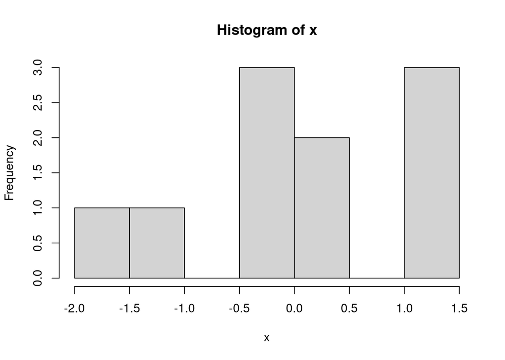

```r
# R code goes here
x <- rnorm(10)    # random sample from normal distribution
hist(x)           # plot density
```

Try increasing the number of draws from the normal distribution and see what happens.

You can also write inline code. For example: the mean of x is 0.065821.

Now you try:

1. What is the minimum value of x?
2. What is the maximum value of x?

Note these numbers will change every time you run the file because x is a random sample.

If you want to ensure reproducibility, you could first use the function `set.seed()`:

```r
# R code goes here
set.seed(12345)
x <- rnorm(10)    # random sample from normal distribution
mean(x)           # compute x's mean
```

```
## [1] -0.1329441
```